# Chapter 2

*Regression and model validation*

Students2014 data (or learning2014 in my case) has 166 observations of 7 variables. The variables are gender, age, attitude (shows persons attitude towards statistics), deep (deep learning), stra (strategic questions), surf (surface learning) and points from exam.

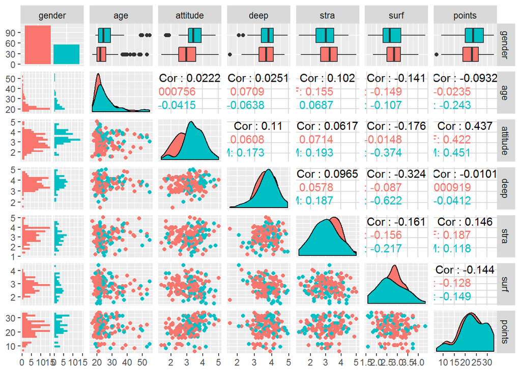

```r
setwd("~/IODS/IODS-project/data")
learning2014<-read.table("learning2014.txt")

library(ggplot2)
library(GGally)

p <- ggpairs(learning2014, mapping = aes(col = gender), lower = list(combo = wrap("facethist", bins = 20)))
p
```

Matrix above is called scatter matrix. For example it shows correlation and scatterplots between all variables.

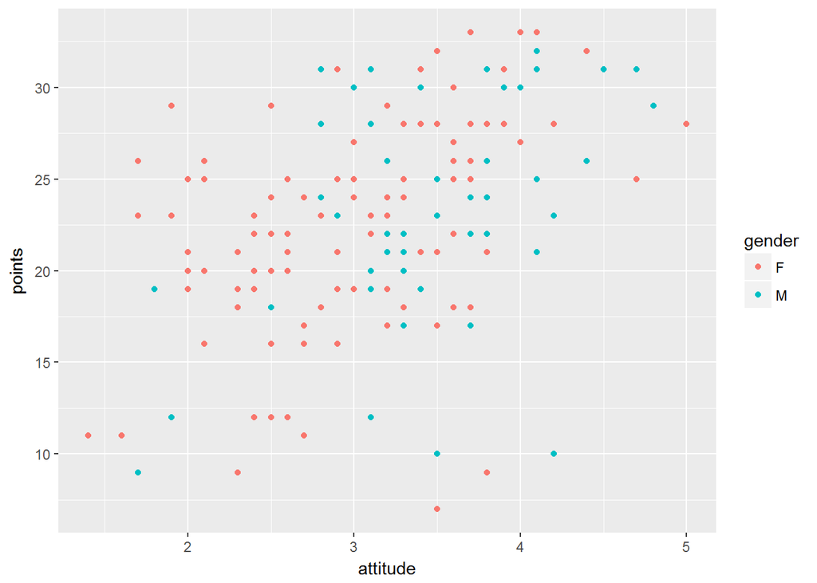

```r
setwd("~/IODS/IODS-project/data")
learning2014<-read.table("learning2014.txt")

library(ggplot2)

p1 <- ggplot(learning2014, aes(x = attitude, y = points, col=gender))
p2 <- p1 + geom_point()
p3 <- p2 + geom_smooth(method = "lm")
p4 <- ggtitle("Student's attitude versus exam points")
p2
```

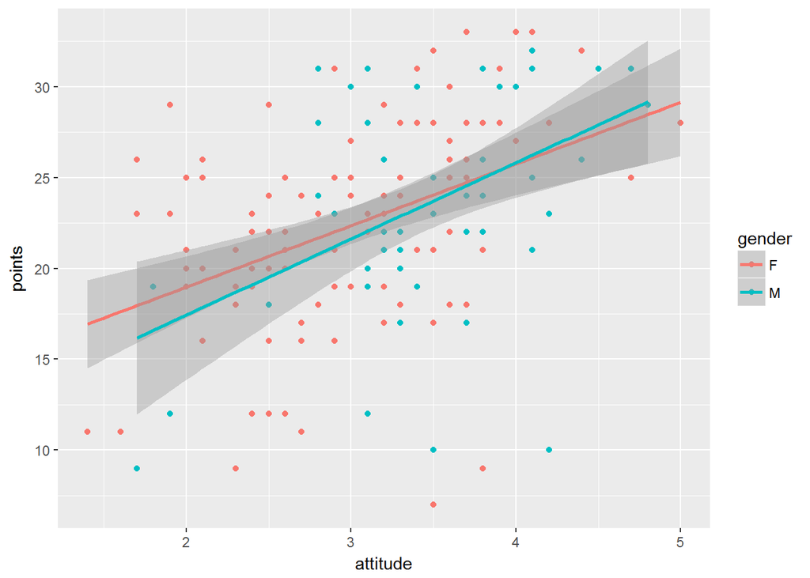

```r
p3
```

The plot above shows attitude versus points in exam with regression lines separated by gender.

```r
my_model2 <- lm(points ~ attitude, data = learning2014)
summary(my_model2)
```

```
##
## Call:
## lm(formula = points ~ attitude, data = learning2014)
##
## Residuals:
##      Min       1Q   Median       3Q      Max
## -16.9763  -3.2119   0.4339   4.1534  10.6645
##
## Coefficients:
##             Estimate Std. Error t value Pr(>|t|)
## (Intercept)  11.6372     1.8303   6.358 1.95e-09 ***
## attitude      3.5255     0.5674   6.214 4.12e-09 ***
## ---
## Signif. codes:  0 '***' 0.001 '**' 0.01 '*' 0.05 '.' 0.1 ' ' 1
##
## Residual standard error: 5.32 on 164 degrees of freedom
## Multiple R-squared:  0.1906, Adjusted R-squared:  0.1856
## F-statistic: 38.61 on 1 and 164 DF,  p-value: 4.119e-09
```

The summary above shows summary of a regression model in which the dependent variable is exam points and the explanatory variable is attitude. I also tried using deep and surf as explanatory variables but they were not statistifically significant because the gotten p-value was > 0.05. It seems that attitude towards statistics has affects the amount of points in exam. Summary shows R-squared value of 0.1906. This value shows linear relation between attitude and points. Because of such low value, the linear relation between variables is fairly low.

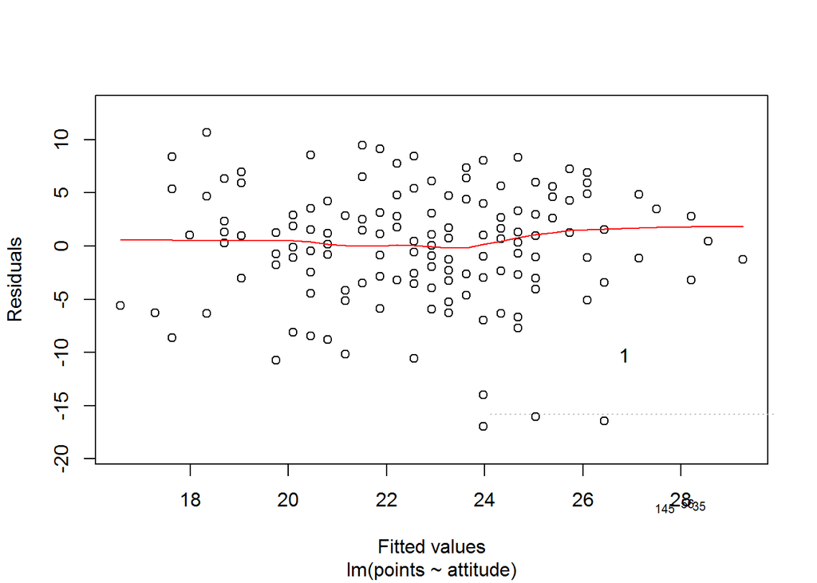

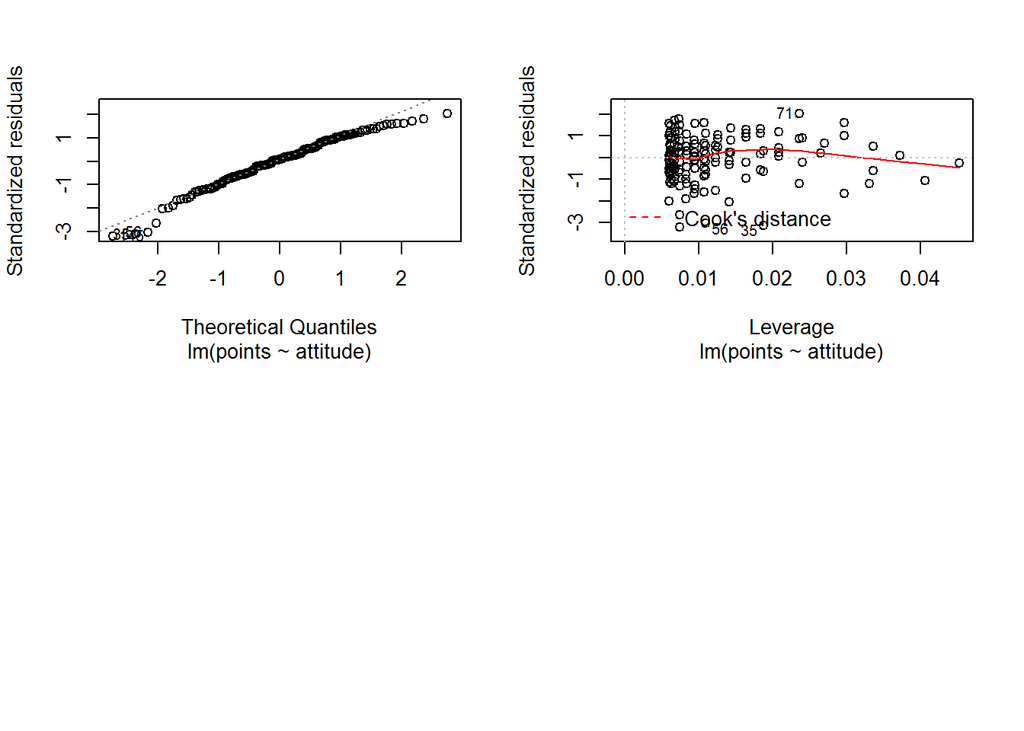

```r
plot(my_model2,which=c(1,2,5),par(mfrow = c(2,2)))
```

The first plot shows where the residuals are compared to fitted values of points ~ attitude. Second plot shows normal QQ-plot which standardizes the values to a standard normal distribution N~(0,1). The new residuals follow the fit line very well. The third plot shows how much leverage a single residual has over the fit line. The highest value of leverage of a single residual is only about 0.04 which is very low. All in all it seems to be a good model.